# Parquet querying time exploration

## Introduction

This page reports the results of two controlled benchmarking experiments examining how DuckDB query performance changes as a function of (1) the number of Parquet files queried and (2) the total number of rows in those files. Both experiments use DuckDB’s `read_parquet()` function to query files directly from disk without loading them into a native DuckDB database first. For background on Parquet’s internal structure and how DuckDB reads Parquet files, see the File Formats, Parquet & DuckDB page in the Theoretical Foundations section of the site.

Two query types are benchmarked throughout:

- **`COUNT(*)`** — counts every row; requires minimal data I/O but must open and process every file and row within each file.
- **`SELECT c5`** — reads a single column across all rows; I/O-intensive but benefits from columnar storage.

## Test 1: Fixed row count, varying file count

### Research question

When the total number of rows is held constant, does splitting that data across more Parquet files increase query time?

### Setup

The first code chunk loads all R packages needed for the experiment, including duckdb for the database engine, ggplot2 and scales for plotting, and glue for string interpolation in SQL queries.

```r
library(duckdb)
library(dplyr)
library(tidyr)
library(ggplot2)
library(scales)
library(glue)
```

Next, we must define all experiment parameters in one place: the total row count, the file split sizes to test, the number of warmup and timed runs, and the directory where Parquet files will be written. Keeping these here makes the experiment easy to re-run with different settings by changing only this chunk.

```r
TOTAL_ROWS <- 1000000
SPLITS <- c(1, 4, 10, 20, 50, 75, 100, 200)
WARMUP_RUNS <- 5
TIMED_RUNS <- 100
PARQUET_DIR <- file.path(tempdir(), "parquet_splits")
```

One million rows are written to disk, split evenly across varying numbers of Parquet files (1 through 200). Every configuration contains exactly the same data(incrementing integers); only the number of files differs. Each file contains ten integer columns (`c1` through `c10`).

```r
con <- dbConnect(duckdb())

dbExecute(
  con,
  glue::glue(
    "
  CREATE TABLE base AS
  SELECT
    row_number() OVER () AS c1,
    row_number() OVER () AS c2,
    row_number() OVER () AS c3,
    row_number() OVER () AS c4,
    row_number() OVER () AS c5,
    row_number() OVER () AS c6,
    row_number() OVER () AS c7,
    row_number() OVER () AS c8,
    row_number() OVER () AS c9,
    row_number() OVER () AS c10
  FROM range({as.integer(TOTAL_ROWS)})
"
  )
)
```

The code chunk above opens an in-memory DuckDB connection and creates a base table of one million rows with ten integer columns, where every value in each column is its row number. This table is the single source of truth that all Parquet splits will be derived from.

The code chunk below loops through each file count in `SPLITS` and writes the base table to disk as that many evenly-sized Parquet files using DuckDB’s `COPY` command. Each split gets its own subfolder, so for example the 50-file configuration writes 50 `.parquet` files each containing 20,000 rows.

```r
dir.create(PARQUET_DIR, showWarnings = FALSE, recursive = TRUE)

for (n_files in SPLITS) {
  folder <- file.path(PARQUET_DIR, sprintf("split_%03d", n_files))
  dir.create(folder, showWarnings = FALSE)
  rows_per_file <- TOTAL_ROWS %/% n_files

  for (i in seq_len(n_files)) {
    offset <- (i - 1) * rows_per_file
    limit <- if (i < n_files) rows_per_file else TOTAL_ROWS - offset
    path <- file.path(folder, sprintf("part_%04d.parquet", i))
    dbExecute(
      con,
      sprintf(
        "COPY (SELECT * FROM base LIMIT %d OFFSET %d) TO '%s' (FORMAT PARQUET)",
        limit,
        offset,
        path
      )
    )
  }
}
```

### Benchmark

Next we define a `bench_query()` function that runs a given SQL query a fixed number of warmup times (discarded) then a fixed number of timed times, returning the mean elapsed time in milliseconds. It then applies this function to both a `COUNT(*)` query and a `SELECT c5` query across each Parquet file split, collecting the results into a single data frame.

```r
bench_query <- function(con, sql, warmup = WARMUP_RUNS, timed = TIMED_RUNS) {
  for (i in seq_len(warmup)) {
    dbGetQuery(con, sql)
  }
  dbGetQuery(con, sql)
  times_ms <- numeric(timed)
  for (i in seq_len(timed)) {
    t0 <- proc.time()[["elapsed"]]
    dbGetQuery(con, sql)
    times_ms[i] <- (proc.time()[["elapsed"]] - t0) * 1000
  }
  mean(times_ms)
}

results <- lapply(SPLITS, function(n_files) {
  glob <- file.path(PARQUET_DIR, sprintf("split_%03d", n_files), "*.parquet")
  data.frame(
    n_files = n_files,
    count_ms = bench_query(
      con,
      sprintf("SELECT count(*) FROM read_parquet('%s')", glob)
    ),
    select_ms = bench_query(
      con,
      sprintf("SELECT c5 FROM read_parquet('%s')", glob)
    )
  )
})

results_df <- bind_rows(results)
```

### Results

```r
results_df |>
  mutate(
    `Files` = n_files,
    `COUNT(*) (ms)` = round(count_ms, 2),
    `SELECT c5 (ms)` = round(select_ms, 2)
  ) |>
  select(`Files`, `COUNT(*) (ms)`, `SELECT c5 (ms)`) |>
  knitr::kable(
    align = "r",
    caption = "Mean query time by file count (1,000,000 rows fixed)"
  )
```

Mean query time by file count (1,000,000 rows fixed)

| Files | COUNT(*) (ms) | SELECT c5 (ms) |
| --- | --- | --- |
| 1 | 1.90 | 6.25 |
| 4 | 1.59 | 4.99 |
| 10 | 1.04 | 3.52 |
| 20 | 1.41 | 3.85 |
| 50 | 2.57 | 4.82 |
| 75 | 3.53 | 5.79 |
| 100 | 4.60 | 6.83 |
| 200 | 8.82 | 11.27 |

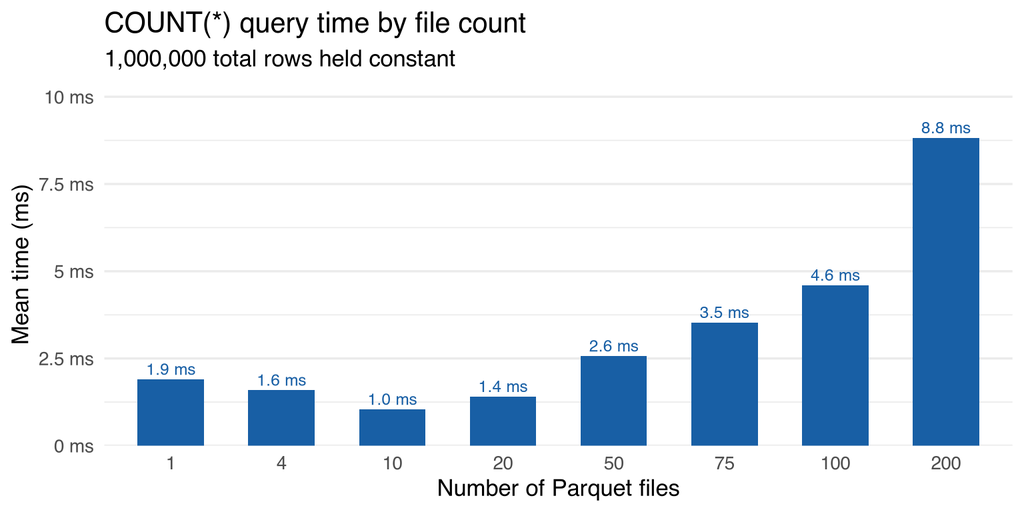

Mean COUNT(*) time as file count increases. Total rows held constant at 1,000,000.

```r
ggplot(results_df, aes(x = factor(n_files), y = count_ms)) +
  geom_col(fill = "#185FA5", width = 0.6) +
  geom_text(
    aes(label = sprintf("%.1f ms", count_ms)),
    vjust = -0.4,
    size = 3.2,
    colour = "#185FA5"
  ) +
  scale_y_continuous(
    labels = function(x) paste0(x, " ms"),
    expand = expansion(mult = c(0, 0.18))
  ) +
  labs(
    x = "Number of Parquet files",
    y = "Mean time (ms)",
    title = "COUNT(*) query time by file count",
    subtitle = "1,000,000 total rows held constant"
  ) +
  theme_minimal(base_size = 13) +
  theme(panel.grid.major.x = element_blank())
```

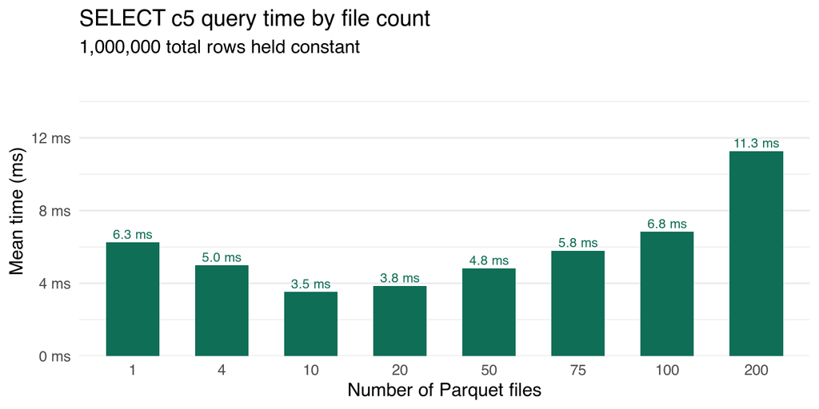

Mean SELECT c5 time as file count increases. Total rows held constant at 1,000,000.

```r
ggplot(results_df, aes(x = factor(n_files), y = select_ms)) +
  geom_col(fill = "#0F6E56", width = 0.6) +
  geom_text(
    aes(label = sprintf("%.1f ms", select_ms)),
    vjust = -0.4,
    size = 3.2,
    colour = "#0F6E56"
  ) +
  scale_y_continuous(
    labels = function(x) paste0(x, " ms"),
    expand = expansion(mult = c(0, 0.18)),
    limits = c(0, max(results_df$select_ms) * 1.2)
  ) +
  labs(
    x = "Number of Parquet files",
    y = "Mean time (ms)",
    title = "SELECT c5 query time by file count",
    subtitle = "1,000,000 total rows held constant"
  ) +
  theme_minimal(base_size = 13) +
  theme(panel.grid.major.x = element_blank())
```

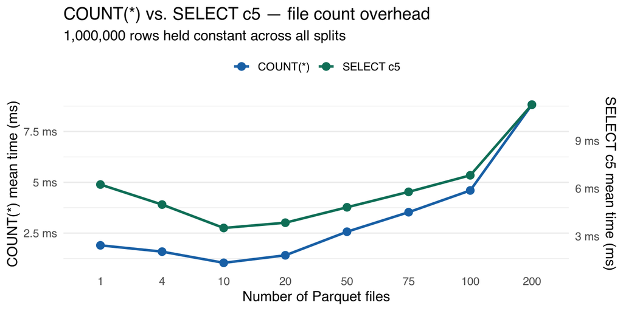

Both query types plotted together. Dual y-axes account for the difference in absolute times between COUNT(*) and SELECT c5.

```r
scale_factor <- max(results_df$select_ms) / max(results_df$count_ms)

results_long <- results_df |>
  mutate(select_ms_scaled = select_ms / scale_factor) |>
  pivot_longer(
    c(count_ms, select_ms_scaled),
    names_to = "query",
    values_to = "ms"
  ) |>
  mutate(
    query = recode(query, count_ms = "COUNT(*)", select_ms_scaled = "SELECT c5")
  )

ggplot(
  results_long,
  aes(x = factor(n_files), y = ms, colour = query, group = query)
) +
  geom_line(linewidth = 1.1) +
  geom_point(size = 3) +
  scale_colour_manual(
    values = c("COUNT(*)" = "#185FA5", "SELECT c5" = "#0F6E56")
  ) +
  scale_y_continuous(
    name = "COUNT(*) mean time (ms)",
    labels = function(x) paste0(round(x, 1), " ms"),
    sec.axis = sec_axis(
      transform = ~ . * scale_factor,
      name = "SELECT c5 mean time (ms)",
      labels = function(x) paste0(round(x), " ms")
    )
  ) +
  labs(
    x = "Number of Parquet files",
    colour = NULL,
    title = "COUNT(*) vs. SELECT c5 — file count overhead",
    subtitle = "1,000,000 rows held constant across all splits"
  ) +
  theme_minimal(base_size = 13) +
  theme(legend.position = "top", panel.grid.major.x = element_blank())
```

### Interpretation

**`SELECT c5`** is less sensitive to file count at low file numbers, because the cost of physically reading and decompressing a full column of data is substantially higher than file-opening overhead. At higher file counts (50+), the coordination overhead becomes more visible and the two trends converge. The key distinction is that for I/O-bound queries, data volume matters more than file count; for metadata-bound queries like `COUNT(*)`, file count matters more than data volume.

## Test 2: Fixed file count, varying row count

### Setup

```r
ROW_COUNTS <- c(100, 10000, 100000, 500000, 1000000, 2000000)
N_FILES <- 100
WARMUP_RUNS <- 5
TIMED_RUNS <- 50
PARQUET_DIR <- file.path(tempdir(), "parquet_rowtest")
```

```r
dir.create(PARQUET_DIR, showWarnings = FALSE, recursive = TRUE)
con <- dbConnect(duckdb())

for (total_rows in ROW_COUNTS) {
  dbExecute(con, "DROP TABLE IF EXISTS base")
  dbExecute(
    con,
    glue(
      "
    CREATE TABLE base AS
    SELECT
      row_number() OVER () AS c1,
      row_number() OVER () AS c2,
      row_number() OVER () AS c3,
      row_number() OVER () AS c4,
      row_number() OVER () AS c5,
      row_number() OVER () AS c6,
      row_number() OVER () AS c7,
      row_number() OVER () AS c8,
      row_number() OVER () AS c9,
      row_number() OVER () AS c10
    FROM range({as.integer(total_rows)})
  "
    )
  )

  single_dir <- file.path(PARQUET_DIR, paste0("single_", total_rows))
  dir.create(single_dir, showWarnings = FALSE)
  dbExecute(
    con,
    glue(
      "COPY base TO '{file.path(single_dir, 'data.parquet')}' (FORMAT PARQUET)"
    )
  )

  multi_dir <- file.path(PARQUET_DIR, paste0("multi_", total_rows))
  dir.create(multi_dir, showWarnings = FALSE)
  rows_per_file <- max(1L, as.integer(total_rows) %/% N_FILES)

  for (i in seq_len(N_FILES)) {
    offset <- (i - 1L) * rows_per_file
    limit <- if (i < N_FILES) rows_per_file else total_rows - offset
    if (limit <= 0) {
      break
    }
    path <- file.path(multi_dir, sprintf("part_%04d.parquet", i))
    dbExecute(
      con,
      glue(
        "COPY (SELECT * FROM base LIMIT {limit} OFFSET {offset}) TO '{path}' (FORMAT PARQUET)"
      )
    )
  }
}
```

### Benchmark

Defines a bench_query() function that runs a given SQL query a fixed number of warmup times (discarded) then a fixed number of timed times, returning the mean elapsed time in milliseconds. It then applies this function to both a COUNT(*) query and a SELECT c5 query across each Parquet file level and row count, collecting the results into a single data frame.

```r
bench_query2 <- function(con, sql, warmup = WARMUP_RUNS, timed = TIMED_RUNS) {
  for (i in seq_len(warmup)) {
    dbGetQuery(con, sql)
  }
  dbGetQuery(con, sql)
  times_ms <- numeric(timed)
  for (i in seq_len(timed)) {
    t0 <- proc.time()[["elapsed"]]
    dbGetQuery(con, sql)
    times_ms[i] <- (proc.time()[["elapsed"]] - t0) * 1000
  }
  mean(times_ms)
}

results2 <- lapply(ROW_COUNTS, function(total_rows) {
  single_path <- file.path(
    PARQUET_DIR,
    paste0("single_", total_rows),
    "data.parquet"
  )
  multi_glob <- file.path(
    PARQUET_DIR,
    paste0("multi_", total_rows),
    "*.parquet"
  )
  data.frame(
    total_rows = total_rows,
    single_count_ms = bench_query2(
      con,
      glue("SELECT count(*) FROM read_parquet('{single_path}')")
    ),
    multi_count_ms = bench_query2(
      con,
      glue("SELECT count(*) FROM read_parquet('{multi_glob}')")
    ),
    single_select_ms = bench_query2(
      con,
      glue("SELECT c5 FROM read_parquet('{single_path}')")
    ),
    multi_select_ms = bench_query2(
      con,
      glue("SELECT c5 FROM read_parquet('{multi_glob}')")
    )
  )
})

results_df2 <- bind_rows(results2)
```

### Results

```r
results_df2 |>
  mutate(
    `Total rows` = format(total_rows, big.mark = ","),
    `COUNT — 1 file (ms)` = round(single_count_ms, 2),
    `COUNT — 50 files (ms)` = round(multi_count_ms, 2),
    `SELECT — 1 file (ms)` = round(single_select_ms, 2),
    `SELECT — 50 files (ms)` = round(multi_select_ms, 2)
  ) |>
  select(6:10) |>
  knitr::kable(
    align = "r",
    caption = "Mean query time by row count (file count fixed at 1 vs. 50)"
  )
```

| Total rows | COUNT — 1 file (ms) | COUNT — 50 files (ms) | SELECT — 1 file (ms) | SELECT — 50 files (ms) |
| --- | --- | --- | --- | --- |
| 1e+02 | 0.44 | 4.68 | 0.42 | 4.58 |
| 1e+04 | 0.40 | 4.60 | 0.46 | 4.66 |
| 1e+05 | 0.58 | 4.74 | 0.98 | 5.14 |
| 5e+05 | 0.46 | 4.56 | 2.06 | 5.90 |
| 1e+06 | 0.48 | 4.58 | 2.94 | 7.44 |
| 2e+06 | 0.58 | 4.52 | 6.98 | 11.12 |

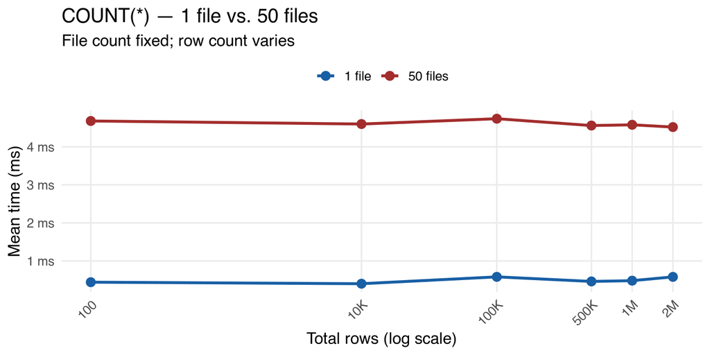

```r
count_long2 <- results_df2 |>
  select(total_rows, single_count_ms, multi_count_ms) |>
  pivot_longer(-total_rows, names_to = "condition", values_to = "mean_ms") |>
  mutate(
    condition = recode(
      condition,
      single_count_ms = "1 file",
      multi_count_ms = "50 files"
    )
  )

ggplot(
  count_long2,
  aes(x = total_rows, y = mean_ms, colour = condition, group = condition)
) +
  geom_line(linewidth = 1.1) +
  geom_point(size = 3) +
  scale_x_log10(
    labels = function(x) {
      ifelse(
        x >= 1e6,
        paste0(x / 1e6, "M"),
        ifelse(x >= 1e3, paste0(x / 1e3, "K"), x)
      )
    },
    breaks = ROW_COUNTS,
    guide = guide_axis(angle = 45)
  ) +
  scale_y_continuous(labels = function(x) paste0(round(x, 2), " ms")) +
  scale_colour_manual(
    values = c("1 file" = "#185FA5", "50 files" = "#A32D2D")
  ) +
  labs(
    x = "Total rows (log scale)",
    y = "Mean time (ms)",
    colour = NULL,
    title = "COUNT(*) — 1 file vs. 50 files",
    subtitle = "File count fixed; row count varies"
  ) +
  theme_minimal(base_size = 13) +
  theme(legend.position = "top", panel.grid.minor = element_blank())
```

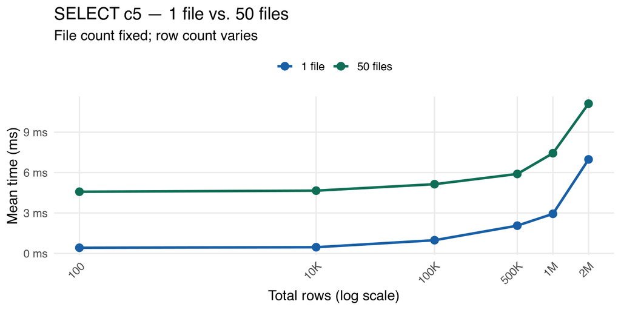

SELECT c5 mean time by total row count. Both series grow together as data volume increases; the gap between them narrows relative to total query time.

```r
select_long2 <- results_df2 |>
  select(total_rows, single_select_ms, multi_select_ms) |>
  pivot_longer(-total_rows, names_to = "condition", values_to = "mean_ms") |>
  mutate(
    condition = recode(
      condition,
      single_select_ms = "1 file",
      multi_select_ms = "50 files"
    )
  )

ggplot(
  select_long2,
  aes(x = total_rows, y = mean_ms, colour = condition, group = condition)
) +
  geom_line(linewidth = 1.1) +
  geom_point(size = 3) +
  scale_x_log10(
    labels = function(x) {
      ifelse(
        x >= 1e6,
        paste0(x / 1e6, "M"),
        ifelse(x >= 1e3, paste0(x / 1e3, "K"), x)
      )
    },
    breaks = ROW_COUNTS,
    guide = guide_axis(angle = 45)
  ) +
  scale_y_continuous(labels = function(x) paste0(round(x, 2), " ms")) +
  scale_colour_manual(
    values = c("1 file" = "#185FA5", "50 files" = "#0F6E56")
  ) +
  labs(
    x = "Total rows (log scale)",
    y = "Mean time (ms)",
    colour = NULL,
    title = "SELECT c5 — 1 file vs. 50 files",
    subtitle = "File count fixed; row count varies"
  ) +
  theme_minimal(base_size = 13) +
  theme(legend.position = "top", panel.grid.minor = element_blank())
```

## Conclusion

Taken together, the two experiments reveal a consistent pattern in how DuckDB handles Parquet files directly from disk. File count and row count impose costs through different mechanisms and affect query types differently.

For **`SELECT c5`**, which is a basic form of column-based querying, row count and data volume have a greater impact on query efficiency compared to transactional row-based query’s. The cost of reading and decompressing a column grows with the number of rows, and per-file overhead is comparatively smaller.

The practical implication is that the optimal Parquet file organization depends on the query pattern. Workloads dominated by lightweight aggregations and metadata queries benefit from fewer, larger files. Workloads involving large column scans across many rows are less sensitive to file count and may benefit from parallelism across multiple files. Neither extreme, one massive file or thousands of tiny files, is universally optimal.